# EVEN more linear Regression with brms (Exercise)

Florian Pätzold, 977687

06/03/2020

## Exercises

### Exercise 1

I prepared an aggregated data frame `dolphin_agg` for you.

```r
# aggregate
dolphin_agg <- dolphin %>%
  group_by(group, exemplar) %>%
  dplyr::summarize(MAD = median(MAD, na.rm = TRUE),
                   RT = median(RT, na.rm = TRUE)) %>%
  mutate(log_RT = log(RT))
```

### (a)

Standardize (“z-transform”) `log_RT` such that the mean is at zero and 1 unit corresponds to the standard deviation. Name it `log_RT_s`.

```r
dolphin_agg$log_RT_s <- scale(dolphin_agg$log_RT, scale = TRUE)
```

### (b)

Run a linear model with `brms` that predicts `MAD` based on `log_RT_s`, `group`, and their two-way interaction. Run 2000 iterations and 6 chains.

```r
model1 <- brm(
  MAD ~ log_RT_s * group,
  data = dolphin_agg,
  iter = 2000,
  chains = 6
)
```

[output not shown]

### (c)

Plot `MAD` (y) against `log_RT_s` (x) in a scatter plot and color-code for `group`. Plot the regression lines for the click and the touch group into the plot and don’t forget to take possible interactions into account.

```r
summary(model1)
```

```
##  Family: gaussian
##   Links: mu = identity; sigma = identity
## Formula: MAD ~ log_RT_s * group
##    Data: dolphin_agg (Number of observations: 38)
## Samples: 6 chains, each with iter = 2000; warmup = 1000; thin = 1;
##          total post-warmup samples = 6000
##
## Population-Level Effects:
##                     Estimate Est.Error l-95% CI u-95% CI Rhat Bulk_ESS Tail_ESS
## Intercept              66.29      7.58    51.45    81.12 1.00     4654     4048
## log_RT_s               16.69      7.36     2.48    31.13 1.00     3782     3890
## grouptouch            -35.12     10.78   -56.36   -13.94 1.00     5209     4340
## log_RT_s:grouptouch   -11.17     11.04   -32.83    10.35 1.00     4054     4171
##
## Family Specific Parameters:
##       Estimate Est.Error l-95% CI u-95% CI Rhat Bulk_ESS Tail_ESS
## sigma    27.57      3.43    21.83    35.40 1.00     4989     3682
##
## Samples were drawn using sampling(NUTS). For each parameter, Bulk_ESS
## and Tail_ESS are effective sample size measures, and Rhat is the potential
## scale reduction factor on split chains (at convergence, Rhat = 1).
```

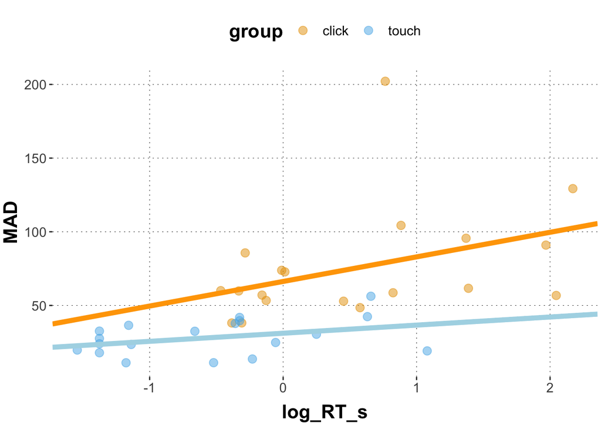

```r
Intercept = summary(model1)$fixed[1]
log_RT_s = summary(model1)$fixed[2]
Grouptouch = summary(model1)$fixed[3]
Interaction = summary(model1)$fixed[4]

dolphin_agg %>%
  ggplot(aes(x = log_RT_s, y = MAD, color = group)) +
  geom_point(size = 3, alpha = 0.5) +
  geom_abline(intercept = Intercept, slope = log_RT_s, color = "orange", size = 2) +
  geom_abline(intercept = Intercept + Grouptouch, slope = log_RT_s + Interaction,
              color = "lightblue", size = 2)
```

### (d)

Specify very skeptic priors for all three coefficients. Use a normal distribution with mean = 0, and sd = 10. Rerun the model with those priors.

```r
priors_model2_strict <- c(set_prior("normal(0,10)", class = "b"))

model2 <- brm(
  MAD ~ log_RT_s * group,
  data = dolphin_agg,
  iter = 2000,
  chains = 6,
  prior = priors_model2_strict
)
```

```
## Trying to compile a simple C file
```

[output not shown]

### (e)

Compare the model output of model1 to model2. What are the differences and what are the reasons for these differences?

```r
summary(model1)
```

```
##  Family: gaussian
##   Links: mu = identity; sigma = identity
## Formula: MAD ~ log_RT_s * group
##    Data: dolphin_agg (Number of observations: 38)
## Samples: 6 chains, each with iter = 2000; warmup = 1000; thin = 1;
##          total post-warmup samples = 6000
##
## Population-Level Effects:
##                     Estimate Est.Error l-95% CI u-95% CI Rhat Bulk_ESS Tail_ESS
## Intercept              66.29      7.58    51.45    81.12 1.00     4654     4048
## log_RT_s               16.69      7.36     2.48    31.13 1.00     3782     3890
## grouptouch            -35.12     10.78   -56.36   -13.94 1.00     5209     4340
## log_RT_s:grouptouch   -11.17     11.04   -32.83    10.35 1.00     4054     4171
##
## Family Specific Parameters:
##       Estimate Est.Error l-95% CI u-95% CI Rhat Bulk_ESS Tail_ESS
## sigma    27.57      3.43    21.83    35.40 1.00     4989     3682
##
## Samples were drawn using sampling(NUTS). For each parameter, Bulk_ESS
## and Tail_ESS are effective sample size measures, and Rhat is the potential
## scale reduction factor on split chains (at convergence, Rhat = 1).
```

```r
summary(model2)
```

```
##  Family: gaussian
##   Links: mu = identity; sigma = identity
## Formula: MAD ~ log_RT_s * group
##    Data: dolphin_agg (Number of observations: 38)
## Samples: 6 chains, each with iter = 2000; warmup = 1000; thin = 1;
##          total post-warmup samples = 6000
##
## Population-Level Effects:
##                     Estimate Est.Error l-95% CI u-95% CI Rhat Bulk_ESS Tail_ESS
## Intercept              60.35      6.19    48.01    72.41 1.00     6594     4540
## log_RT_s               13.84      5.30     3.39    23.95 1.00     4977     4538
## grouptouch            -17.66      7.71   -32.29    -2.40 1.00     6798     3920
## log_RT_s:grouptouch    -0.90      7.14   -14.86    13.46 1.00     5798     4624
##
## Family Specific Parameters:
##       Estimate Est.Error l-95% CI u-95% CI Rhat Bulk_ESS Tail_ESS
## sigma    28.57      3.62    22.49    36.62 1.00     5826     4703
##
## Samples were drawn using sampling(NUTS). For each parameter, Bulk_ESS
## and Tail_ESS are effective sample size measures, and Rhat is the potential
## scale reduction factor on split chains (at convergence, Rhat = 1).
```

```r
# The priors for model1's predictors are by default flat priors which means that the model assumes all parameter values for the coefficients equally likely, thus our posterior estimates are overall greater than in model2, where our strict prior belief "dominates" the posterior, i.e. drags the posterior estimates of our coefficients closer to the mean of our prior normal distribution, namely 0.
```

## Exercise 2 *HOMEWORK*

- If you need help, take a look at the suggested readings in the lecture, make use of the Forum, make use of the Forum, and also make use of the Forum.
- Use this exercise Rmd-file, solve the exercises marked as homework (this section here) and save the file with your student number and name in the ‘author’ heading.
- ‘Knit’ the document to produce a HTML file. If knitting fails, make use of the Forum ;)
- **Please do not suppress the code in the HTML-Output!**
- Create a ZIP archive called “MATRIKELNR_Lastname_Firstname_ABDA_Week3.zip” containing:
  - an R Markdown file “MATRIKELNR_Lastname_Firstname_ABDA_Week3.Rmd” and
  - a knitted HTML document “MATRIKELNR_Lastname_Firstname_ABDA_Week3.html”
- Upload the ZIP archive on Stud.IP in the homework folder before the deadline. You may upload as many times as you like before the deadline, only your final submission will count.

I prepared an aggregated data frame `dolphin_agg2` for you.

```r
# aggregate
dolphin_agg2 <- dolphin %>%
  filter(correct == 1) %>%
  group_by(exemplar, group, condition) %>%
  dplyr::summarize(MAD = median(MAD, na.rm = TRUE),
                   RT = median(RT, na.rm = TRUE)) %>%
  mutate(log_RT = log(RT))

dolphin_agg2
```

```
## # A tibble: 38 x 6
## # Groups:   exemplar, group [38]
##    exemplar  group condition   MAD    RT log_RT
##    <chr>     <chr> <chr>     <dbl> <dbl>  <dbl>
##  1 alligator click Typical    43.0 1637    7.40
##  2 alligator touch Typical    11.1 1350    7.21
##  3 bat       click Atypical   69.9 2042.   7.62
##  4 bat       touch Atypical   14.6 1675    7.42
##  5 butterfly click Atypical  105.  1830.   7.51
##  6 butterfly touch Atypical   12.9 1410.   7.25
##  7 cat       click Typical    53.4 1463    7.29
##  8 cat       touch Typical    23.3 1095    7.00
##  9 chameleon click Typical    56.7 1789    7.49
## 10 chameleon touch Typical    23.7 1498    7.31
## # … with 28 more rows
```

### (a) (10pts)

Run a model predicting MAD based on *standardized* `log_RT`, `group`, `condition`, and *their three-way interaction*. Set a seed = 999.

```r
dolphin_agg2$log_RT_s <- scale(dolphin_agg2$log_RT, scale = TRUE)

model3 <- brm(
  MAD ~ log_RT_s * group * condition,
  data = dolphin_agg2,
  seed = 999
)
```

[output not shown]

### (b) (20 pts)

Look at the output. Extract posterior means and 95% CrIs for the following predictor level combinations. One row corresponds to one concrete combination of levels. (Tip: check your results by plotting them against the data)

- Combination1: log_RT_s == 0; group == click; condition == Atypical
- Combination2: log_RT_s == 0; group == touch; condition == Atypical
- Combination3: log_RT_s == 1; group == touch; condition == Typical
- Combination4: log_RT_s == 2; group == touch; condition == Atypical

```r
summary(model3)
```

```
##  Family: gaussian
##   Links: mu = identity; sigma = identity
## Formula: MAD ~ log_RT_s * group * condition
##    Data: dolphin_agg2 (Number of observations: 38)
## Samples: 4 chains, each with iter = 2000; warmup = 1000; thin = 1;
##          total post-warmup samples = 4000
##
## Population-Level Effects:
##                                      Estimate Est.Error l-95% CI u-95% CI Rhat
## Intercept                               95.90     20.40    57.16   135.75 1.01
## log_RT_s                                 8.00     13.34   -18.45    34.33 1.00
## grouptouch                             -61.70     23.12  -108.82   -16.63 1.00
## conditionTypical                       -36.84     21.55   -79.32     4.52 1.01
## log_RT_s:grouptouch                     -1.96     23.63   -49.99    43.93 1.00
## log_RT_s:conditionTypical               -2.84     16.68   -36.35    29.78 1.01
## grouptouch:conditionTypical             27.88     26.59   -23.89    80.41 1.00
## log_RT_s:grouptouch:conditionTypical    -0.34     27.41   -53.14    54.74 1.00
##                                      Bulk_ESS Tail_ESS
## Intercept                                1273     1643
## log_RT_s                                 1233     1728
## grouptouch                               1222     1712
## conditionTypical                         1278     1593
## log_RT_s:grouptouch                      1504     2096
## log_RT_s:conditionTypical                1457     1940
## grouptouch:conditionTypical              1377     1899
## log_RT_s:grouptouch:conditionTypical     1627     2165
##
## Family Specific Parameters:
##       Estimate Est.Error l-95% CI u-95% CI Rhat Bulk_ESS Tail_ESS
## sigma    24.01      3.13    18.82    31.16 1.00     2335     2640
##
## Samples were drawn using sampling(NUTS). For each parameter, Bulk_ESS
## and Tail_ESS are effective sample size measures, and Rhat is the potential
## scale reduction factor on split chains (at convergence, Rhat = 1).
```

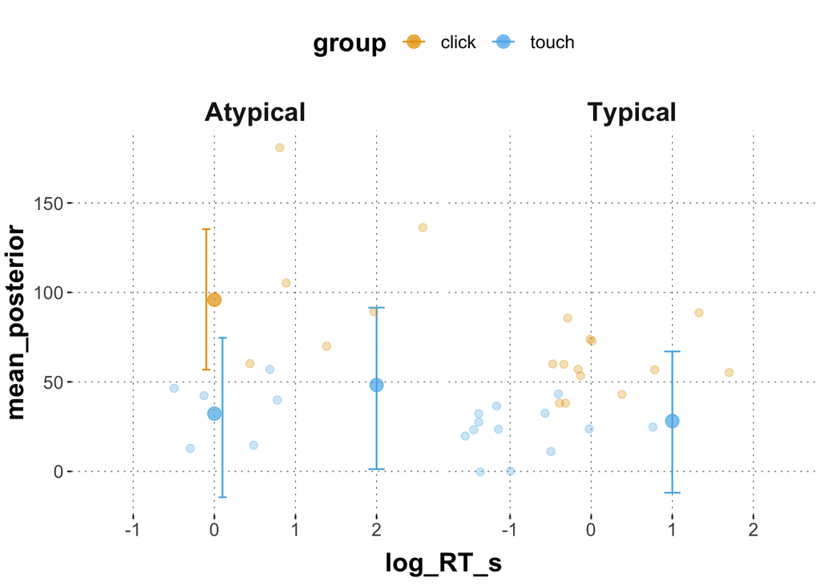

```r
posteriors3 <- model3 %>%
  spread_draws(b_Intercept, b_log_RT_s, b_grouptouch, b_conditionTypical,
               `b_log_RT_s:grouptouch`, `b_log_RT_s:conditionTypical`,
               `b_grouptouch:conditionTypical`, `b_log_RT_s:grouptouch:conditionTypical`) %>%
  mutate(Combination1 = b_Intercept,
         Combination2 = b_Intercept + b_grouptouch + `b_log_RT_s:grouptouch`,
         Combination3 = b_Intercept + b_grouptouch + b_conditionTypical +
           b_log_RT_s + `b_log_RT_s:grouptouch` + `b_log_RT_s:conditionTypical` +
           `b_grouptouch:conditionTypical` + `b_log_RT_s:grouptouch:conditionTypical`,
         Combination4 = b_Intercept + b_grouptouch + b_log_RT_s + b_log_RT_s +
           `b_log_RT_s:grouptouch`) %>%
  select(Combination1, Combination2, Combination3, Combination4) %>%
  gather(key = "parameter", value = "posterior") %>%
  mutate(group = ifelse(parameter == "Combination1", "click", "touch"),
         condition = ifelse(parameter == "Combination3", "Typical", "Atypical"),
         log_RT_s = ifelse(parameter == "Combination1" | parameter == "Combination2", 0,
                           ifelse(parameter == "Combination3", 1, 2)))

posteriors_agg3 <- posteriors3 %>%
  group_by(group, condition, log_RT_s) %>%
  summarise(mean_posterior = mean(posterior),
            `95lowerCrI` = HDInterval::hdi(posterior, credMass = 0.95)[1],
            `95higherCrI` = HDInterval::hdi(posterior, credMass = 0.95)[2])

# Let's plot the posterior means against the data to check if they are representative of our data.
posteriors_agg3 %>%
  ggplot(aes(x = log_RT_s, y = mean_posterior, color = group, fill = group)) +
  geom_errorbar(aes(x = log_RT_s, ymin = `95lowerCrI`, ymax = `95higherCrI`), width = 0.2,
                position = position_dodge(0.4)) +
  geom_point(size = 3.5, alpha = 0.7) +
  geom_point(data = dolphin_agg2, aes(x = log_RT_s, y = MAD), alpha = 0.3, size = 2) +
  facet_grid(~ condition)
```